# Master Thesis: A Causal Test of the Law of 1/n and its Mechanisms – Descriptive Statistics

Florian Fox

2022-10-21

# Introduction

Note: Since this script serves as exploratory data analysis with respect to the research question, I use the `data` data set, i. e. the data set running until 2021. In the paper, I only use data until 2014. For the LaTeX export, I obviously limit the data set to the data used in the analysis scripts.

# Load data and packages

```r
library(tidyverse)
library(haven)
library(reshape2)
```

```r
library(ggcorrplot)
library(xtable)
source("functions/functions.R")
```

```r
data <-
  readRDS("data/gemeinderatswahlen_alldata.rds")
thresholds <- haven::read_stata("data/All_discs.dta")
```

```r
# similar data set definition as in "Analysis.Rmd"
d_rdd_bivariate <- data %>%
  select(ln_gross_expenditure_pc, total_seats, inhabs_rel_to_cutoff, above_cutoff, inhabitants_treshold_factor, inhabitants_treshold, year, ags, election_year, state, closest, clean_disc_acc_Höhmann, clean_disc_acc_to_my_research) %>%
  drop_na(ln_gross_expenditure_pc, total_seats, inhabs_rel_to_cutoff) %>%
  # Repeat (bandwidth) window calculation for data subsets
  mutate(
    closest = base::rank(abs(inhabs_rel_to_cutoff), ties.method = "last"),
    closest = closest/max(closest),
  )
d_rdd_bivariate2 <- data %>%
  select(ln_gross_expenditure_pc, total_seats, inhabs_rel_to_cutoff, above_cutoff, inhabitants_treshold_factor, inhabitants_treshold, year, ags, election_year, state, closest, clean_disc_acc_Höhmann, clean_disc_acc_to_my_research, by_law_seats) %>% # add by_law_seats here
  drop_na(ln_gross_expenditure_pc, total_seats, inhabs_rel_to_cutoff)
d_rdd <- data %>%
  select(ln_gross_expenditure_pc, total_seats, inhabs_rel_to_cutoff, above_cutoff, closest,
         inhabitants_treshold_factor, inhabitants_treshold, year, ags, state,
         inh_tot, pop_over65, unempl_rate, total_area_ha,
         share_working_age, kreisfreie_stadt, stadt, years_since_last_elec) %>%
  drop_na() %>%
  # Repeat (bandwidth) window calculation for data subsets
  mutate(
    closest = base::rank(abs(inhabs_rel_to_cutoff), ties.method = "last"),
    closest = closest/max(closest),
  )
```

```r
options(scipen = 20)
theme_set(theme_minimal())
```

# First look at the data

```r
glimpse(data)
```

```
## Rows: 231,933
## Columns: 102
## $ No                                   <dbl> 1, 2, 3, 4, 5, 6, 7, 8, 9, 10, 11…
## $ state                                <dbl> 1, 1, 1, 1, 1, 1, 1, 1, 1, 1, 1, …
## $ county_id                            <dbl> 1001, 1001, 1001, 1001, 1001, 100…
## $ ags_string                           <chr> "1001000", "1001000", "1001000", …
## $ ags_regstat                          <chr> "01001", "01001", "01001", "01001…
## $ ags                                  <dbl> 1001000, 1001000, 1001000, 100100…
## $ year                                 <dbl> 2002, 2003, 2004, 2005, 2006, 200…
## $ town                                 <chr> "Flensburg, krsfr. Stadt", "Flens…
## $ inh_tot                              <dbl> 84704, 85300, 85762, 86080, 86630…
## $ pop_over65                           <dbl> 0.1814554, 0.1843728, 0.1876122, …
## $ unempl_rate                          <dbl> 0.09278106, 0.10309016, 0.1042453…
## $ total_taxpayers                      <dbl> NA, NA, 27502, 27502, 35210, 3521…
## $ total_area_ha                        <dbl> 5646, 5646, 5638, 5638, 5638, 563…
```

[output cut: 89 more lines]

# Univariate statistics

## NAs

```r
data %>%
  summarize(across(.cols = everything(),
                   .fns = ~sum(is.na(.))/n()
                   ))
```

| No | state | county_id | ags_string | ags_regstat | ags | year | town | inh_tot | pop_over65 | unempl_rate | total_taxpayers | total_area_ha | area_agricultural | area_forest | share_working_age | area_buildings_firms__industry | Svpflicht_Besch_Residence | Svpflicht_Besch_Work | ags_num | election_id | election_date | total_seats | eligible_voters | voters | valid_votes | kreisfreie_stadt | stadt | exact_pop | exact_pop_date | … |
| --- | --- | --- | --- | --- | --- | --- | --- | --- | --- | --- | --- | --- | --- | --- | --- | --- | --- | --- | --- | --- | --- | --- | --- | --- | --- | --- | --- | --- | --- | --- |
| 0 | 0 | 0.09297513 | 0 | 0 | 0 | 0 | 0 | 0.04663847 | 0.09703664 | 0.1253034 | 0.2267724 | 0.0931519 | 0.1025124 | 0.1038964 | 0.1004471 | 0.3512825 | 0.4275761 | 0.5092074 | 0.04067554 | 0.04067554 | 0.04067554 | 0.06873106 | 0.4895595 | 0.4895595 | 0.5251129 | 0.04067554 | 0.06051748 | 0.1752403 | 0.2699271 | … |

```r
data %>%
  group_by(state) %>%
  summarize(across(.cols = everything(),
                   .fns = ~sum(is.na(.))/n()
                   ))
```

| state | No | county_id | ags_string | ags_regstat | ags | year | town | inh_tot | pop_over65 | unempl_rate | total_taxpayers | total_area_ha | area_agricultural | area_forest | share_working_age | area_buildings_firms__industry | Svpflicht_Besch_Residence | Svpflicht_Besch_Work | ags_num | election_id | election_date | total_seats | eligible_voters | voters | valid_votes | kreisfreie_stadt | stadt | exact_pop | exact_pop_date | … |
| --- | --- | --- | --- | --- | --- | --- | --- | --- | --- | --- | --- | --- | --- | --- | --- | --- | --- | --- | --- | --- | --- | --- | --- | --- | --- | --- | --- | --- | --- | --- |
| 1 | 0 | 0.09913059 | 0 | 0 | 0 | 0 | 0 | 0.04987900 | 0.13041140 | 0.14040513 | 0.2006364 | 0.09913059 | 0.09913059 | 0.10482208 | 0.13883660 | 0.3473156 | 0.4025276 | 0.5027785 | 0.0018822264 | 0.0018822264 | 0.0018822264 | 0.249484628 | 1.000000000 | 1.000000000 | 1.000000000 | 0.0018822264 | 0.0018822264 | 0.251097965 | 0.2510979654 | … |
| 3 | 0 | 0.09515649 | 0 | 0 | 0 | 0 | 0 | 0.04757825 | 0.10437982 | 0.11012550 | 0.2058364 | 0.09515649 | 0.09515649 | 0.09671892 | 0.10437982 | 0.3236732 | 0.4146464 | 0.4380324 | 0.0111385515 | 0.0111385515 | 0.0111385515 | 0.058363994 | 0.011138551 | 0.011138551 | 0.011138551 | 0.0111385515 | 0.0111385515 | 1.000000000 | 1.0000000000 | … |
| 5 | 0 | 0.10030318 | 0 | 0 | 0 | 0 | 0 | 0.05141486 | 0.10156645 | 0.10282971 | 0.2014907 | 0.10030318 | 0.10030318 | 0.10030318 | 0.10030318 | 0.3496716 | 0.4017180 | 0.4017180 | 0.0002526529 | 0.0002526529 | 0.0002526529 | 0.005937342 | 0.005937342 | 0.005937342 | 0.005937342 | 0.0002526529 | 0.0002526529 | 0.005937342 | 0.0002526529 | … |
| 6 | 0 | 0.09887535 | 0 | 0 | 0 | 0 | 0 | 0.04943768 | 0.10262418 | 0.10332709 | 0.2000937 | 0.09887535 | 0.09899250 | 0.09934396 | 0.10262418 | 0.3475867 | 0.4020619 | 0.4027648 | 0.0039831303 | 0.0039831303 | 0.0039831303 | 0.003983130 | 1.000000000 | 1.000000000 | 1.000000000 | 0.0039831303 | 0.0039831303 | 0.003983130 | 0.0039831303 | … |
| 7 | 0 | 0.09948133 | 0 | 0 | 0 | 0 | 0 | 0.04976236 | 0.09950303 | 0.13288049 | 0.2039975 | 0.09995877 | 0.09998047 | 0.10152130 | 0.11163437 | 0.3499859 | 0.4036763 | 0.5778988 | 0.0031033660 | 0.0031033660 | 0.0031033660 | 0.003103366 | 1.000000000 | 1.000000000 | 1.000000000 | 0.0031033660 | 0.0031033660 | 0.003255279 | 0.0031033660 | … |
| 8 | 0 | 0.09973730 | 0 | 0 | 0 | 0 | 0 | 0.04991394 | 0.09978259 | 0.10200199 | 0.2018752 | 0.09973730 | 0.09973730 | 0.10068847 | 0.09987318 | 0.3490805 | 0.4039768 | 0.4133074 | 0.0029441073 | 0.0029441073 | 0.0029441073 | 0.002944107 | 0.002944107 | 0.002944107 | 0.002944107 | 0.0029441073 | 0.0029441073 | 0.002944107 | 1.0000000000 | … |
| 9 | 0 | 0.09995622 | 0 | 0 | 0 | 0 | 0 | 0.04997811 | 0.09995622 | 0.09995622 | 0.1999611 | 0.09995622 | 0.09995622 | 0.10017511 | 0.09995622 | 0.3499684 | 0.3999708 | 0.4063670 | 0.0000000000 | 0.0000000000 | 0.0000000000 | 0.000000000 | 0.000000000 | 0.000000000 | 0.000000000 | 0.0000000000 | 0.0000000000 | 0.000000000 | 0.0000000000 | … |
| 10 | 0 | 0.10172745 | 0 | 0 | 0 | 0 | 0 | 0.05086372 | 0.10172745 | 0.10172745 | 0.2015355 | 0.10172745 | 0.10172745 | 0.10172745 | 0.10172745 | 0.3512476 | 0.4011516 | 0.4011516 | 0.0019193858 | 0.0019193858 | 0.0019193858 | 0.001919386 | 1.000000000 | 1.000000000 | 1.000000000 | 0.0019193858 | 0.0019193858 | 0.001919386 | 0.0019193858 | … |
| 12 | 0 | 0.09416281 | 0 | 0 | 0 | 0 | 0 | 0.04708140 | 0.09427571 | 0.11967935 | 0.2434233 | 0.09416281 | 0.24252004 | 0.24285876 | 0.09427571 | 0.4780400 | 0.4333296 | 0.4533138 | 0.3391667608 | 0.3391667608 | 0.3391667608 | 0.339166761 | 0.339166761 | 0.339166761 | 0.339166761 | 0.3391667608 | 0.8587557864 | 0.858755786 | 0.8587557864 | … |
| 13 | 0 | 0.08995168 | 0 | 0 | 0 | 0 | 0 | 0.04534754 | 0.09032338 | 0.24705737 | 0.3103705 | 0.08995168 | 0.09001363 | 0.09038533 | 0.09081898 | 0.3207781 | 0.4718127 | 0.5561269 | 0.1494858134 | 0.1494858134 | 0.1494858134 | 0.149485813 | 0.153202825 | 0.153202825 | 0.153202825 | 0.1494858134 | 0.1494858134 | 0.160389047 | 0.1603890472 | … |

[output cut: 3 more lines]

```r
data %>%
  group_by(year) %>%
  summarize(across(.cols = everything(),
                   .fns = ~sum(is.na(.))/n()
                   ))
```

| year | No | state | county_id | ags_string | ags_regstat | ags | town | inh_tot | pop_over65 | unempl_rate | total_taxpayers | total_area_ha | area_agricultural | area_forest | share_working_age | area_buildings_firms__industry | Svpflicht_Besch_Residence | Svpflicht_Besch_Work | ags_num | election_id | election_date | total_seats | eligible_voters | voters | valid_votes | kreisfreie_stadt | stadt | exact_pop | exact_pop_date | … |
| --- | --- | --- | --- | --- | --- | --- | --- | --- | --- | --- | --- | --- | --- | --- | --- | --- | --- | --- | --- | --- | --- | --- | --- | --- | --- | --- | --- | --- | --- | --- |
| 2002 | 0 | 0 | 0 | 0 | 0 | 0 | 0 | 0.00000000000 | 0.012299749 | 0.034621517 | 1.0000000000 | 0.000000000 | 0.06711715132 | 0.06711715132 | 0.012299749 | 0.14357300129 | 1.0000000000 | 1.00000000 | 0.0723559335 | 0.0723559335 | 0.0723559335 | 0.0723559335 | 0.4858401 | 0.4858401 | 0.5793030 | 0.0723559335 | 0.0723559335 | 0.16118746 | 0.2446284 | … |
| 2003 | 0 | 0 | 0 | 0 | 0 | 0 | 0 | 0.00000000000 | 0.012725261 | 0.029323427 | 1.0000000000 | 0.000000000 | 0.03414479924 | 0.03667404363 | 0.012725261 | 0.20826746759 | 1.0000000000 | 1.00000000 | 0.0401517547 | 0.0401517547 | 0.0401517547 | 0.0401517547 | 0.4694120 | 0.4694120 | 0.5635473 | 0.0401517547 | 0.0401517547 | 0.13183686 | 0.2187006 | … |
| 2004 | 0 | 0 | 0 | 0 | 0 | 0 | 0 | 0.00000000000 | 0.013493976 | 0.032610442 | 0.0005622490 | 0.000000000 | 0.00000000000 | 0.00000000000 | 0.013493976 | 0.00000000000 | 1.0000000000 | 1.00000000 | 0.0385542169 | 0.0385542169 | 0.0385542169 | 0.0385542169 | 0.4740562 | 0.4740562 | 0.5632932 | 0.0385542169 | 0.0385542169 | 0.13228916 | 0.2205622 | … |
| 2005 | 0 | 0 | 0 | 0 | 0 | 0 | 0 | 0.00008087343 | 0.013667610 | 0.025394258 | 0.0004852406 | 0.000000000 | 0.00000000000 | 0.00000000000 | 0.013667610 | 0.00000000000 | 1.0000000000 | 1.00000000 | 0.0393044885 | 0.0393044885 | 0.0393044885 | 0.0393044885 | 0.4773959 | 0.4773959 | 0.5623130 | 0.0393044885 | 0.0393044885 | 0.13327942 | 0.2221593 | … |
| 2006 | 0 | 0 | 0 | 0 | 0 | 0 | 0 | 0.00000000000 | 0.013295501 | 0.029590596 | 0.1655451966 | 0.000000000 | 0.00000000000 | 0.00016214025 | 0.013295501 | 0.01516011350 | 1.0000000000 | 1.00000000 | 0.0391568707 | 0.0391568707 | 0.0391568707 | 0.0391568707 | 0.4774220 | 0.4774220 | 0.5613296 | 0.0391568707 | 0.0391568707 | 0.13311715 | 0.2222132 | … |
| 2007 | 0 | 0 | 0 | 0 | 0 | 0 | 0 | 0.00000000000 | 0.002278831 | 0.029299259 | 0.0000000000 | 0.000000000 | 0.00000000000 | 0.00000000000 | 0.002278831 | 0.00000000000 | 1.0000000000 | 1.00000000 | 0.1224871816 | 0.1224871816 | 0.1224871816 | 0.1224871816 | 0.5596159 | 0.5596159 | 0.5596159 | 0.1224871816 | 0.1224871816 | 0.21583788 | 0.3052820 | … |
| 2008 | 0 | 0 | 0 | 0 | 0 | 0 | 0 | 0.00000000000 | 0.002287021 | 0.154128890 | 0.0000000000 | 0.000000000 | 0.00000000000 | 0.00000000000 | 0.002287021 | 0.00000000000 | 0.0104549539 | 0.21342808 | 0.1272563914 | 0.1272563914 | 0.1272563914 | 0.1272563914 | 0.5238095 | 0.5238095 | 0.5238095 | 0.1272563914 | 0.1615617087 | 0.24757004 | 0.3373356 | … |
| 2009 | 0 | 0 | 0 | 0 | 0 | 0 | 0 | 0.00282932512 | 0.005159358 | 0.137887992 | 0.0115669468 | 0.000000000 | 0.00000000000 | 0.00000000000 | 0.002330032 | 0.00000000000 | 0.0115669468 | 0.20728967 | 0.0600815511 | 0.0600815511 | 0.0600815511 | 0.0608304901 | 0.5044520 | 0.5044520 | 0.5175169 | 0.0600815511 | 0.0949488225 | 0.18898228 | 0.2798535 | … |
| 2010 | 0 | 0 | 0 | 0 | 0 | 0 | 0 | 0.00000000000 | 0.000000000 | 0.082525982 | 0.0903646292 | 0.000000000 | 0.00008807469 | 0.00008807469 | 0.006869826 | 0.00008807469 | 0.0078386472 | 0.19667078 | 0.0044918091 | 0.0044918091 | 0.0044918091 | 0.0052844812 | 0.4735776 | 0.4735776 | 0.4896072 | 0.0044918091 | 0.0413951030 | 0.14285714 | 0.2390347 | … |
| 2011 | 0 | 0 | 0 | 0 | 0 | 0 | 0 | 0.00000000000 | 0.000000000 | 0.006467618 | 0.1576149553 | 0.001949145 | 0.00194914503 | 0.00194914503 | 0.006467618 | 0.00194914503 | 0.1576149553 | 0.25312306 | 0.0764596438 | 0.0764596438 | 0.0764596438 | 0.0772570214 | 0.5432799 | 0.5432799 | 0.5594046 | 0.0764596438 | 0.1135819970 | 0.21210242 | 0.3088509 | … |

[output cut: 10 more lines]

```r
data %>%
  group_by(state, year) %>%
  summarize(across(.cols = everything(),
                   .fns = ~sum(is.na(.))/n()
                   ))
```

| state | year | No | county_id | ags_string | ags_regstat | ags | town | inh_tot | pop_over65 | unempl_rate | total_taxpayers | total_area_ha | area_agricultural | area_forest | share_working_age | area_buildings_firms__industry | Svpflicht_Besch_Residence | Svpflicht_Besch_Work | ags_num | election_id | election_date | total_seats | eligible_voters | voters | valid_votes | kreisfreie_stadt | stadt | exact_pop | exact_pop_date | … |
| --- | --- | --- | --- | --- | --- | --- | --- | --- | --- | --- | --- | --- | --- | --- | --- | --- | --- | --- | --- | --- | --- | --- | --- | --- | --- | --- | --- | --- | --- | --- |
| 1 | 2002 | 0 | 0 | 0 | 0 | 0 | 0 | 0.0000000000 | 0.1203539823 | 0.1230088496 | 1.0000000000 | 0.000000000 | 0.0000000000 | 0.0000000000 | 0.1203539823 | 0.0000000000 | 1.000000000 | 1.000000000 | 0.0017699115 | 0.0017699115 | 0.0017699115 | 0.0017699115 | 1.0000000000 | 1.0000000000 | 1.0000000000 | 0.0017699115 | 0.0017699115 | 0.0035398230 | 0.0035398230 | … |
| 1 | 2003 | 0 | 0 | 0 | 0 | 0 | 0 | 0.0000000000 | 0.1190053286 | 0.1207815275 | 1.0000000000 | 0.000000000 | 0.0000000000 | 0.0000000000 | 0.1190053286 | 0.0000000000 | 1.000000000 | 1.000000000 | 0.0008880995 | 0.0008880995 | 0.0008880995 | 0.0008880995 | 1.0000000000 | 1.0000000000 | 1.0000000000 | 0.0008880995 | 0.0008880995 | 0.0026642984 | 0.0026642984 | … |
| 1 | 2004 | 0 | 0 | 0 | 0 | 0 | 0 | 0.0000000000 | 0.1252220249 | 0.1261101243 | 0.0008880995 | 0.000000000 | 0.0000000000 | 0.0000000000 | 0.1252220249 | 0.0000000000 | 1.000000000 | 1.000000000 | 0.0008880995 | 0.0008880995 | 0.0008880995 | 0.0008880995 | 1.0000000000 | 1.0000000000 | 1.0000000000 | 0.0008880995 | 0.0008880995 | 0.0026642984 | 0.0026642984 | … |
| 1 | 2005 | 0 | 0 | 0 | 0 | 0 | 0 | 0.0008880995 | 0.1252220249 | 0.1252220249 | 0.0000000000 | 0.000000000 | 0.0000000000 | 0.0000000000 | 0.1252220249 | 0.0000000000 | 1.000000000 | 1.000000000 | 0.0008880995 | 0.0008880995 | 0.0008880995 | 0.0008880995 | 1.0000000000 | 1.0000000000 | 1.0000000000 | 0.0008880995 | 0.0008880995 | 0.0026642984 | 0.0026642984 | … |
| 1 | 2006 | 0 | 0 | 0 | 0 | 0 | 0 | 0.0000000000 | 0.1216696270 | 0.1243339254 | 0.0000000000 | 0.000000000 | 0.0000000000 | 0.0000000000 | 0.1216696270 | 0.0000000000 | 1.000000000 | 1.000000000 | 0.0008880995 | 0.0008880995 | 0.0008880995 | 0.0008880995 | 1.0000000000 | 1.0000000000 | 1.0000000000 | 0.0008880995 | 0.0008880995 | 0.0026642984 | 0.0026642984 | … |
| 1 | 2007 | 0 | 0 | 0 | 0 | 0 | 0 | 0.0000000000 | 0.0008888889 | 0.0568888889 | 0.0000000000 | 0.000000000 | 0.0000000000 | 0.0000000000 | 0.0008888889 | 0.0000000000 | 1.000000000 | 1.000000000 | 0.0008888889 | 0.0008888889 | 0.0008888889 | 0.0008888889 | 1.0000000000 | 1.0000000000 | 1.0000000000 | 0.0008888889 | 0.0008888889 | 0.0026666667 | 0.0026666667 | … |
| 1 | 2008 | 0 | 0 | 0 | 0 | 0 | 0 | 0.0000000000 | 0.0008928571 | 0.0116071429 | 0.0000000000 | 0.000000000 | 0.0000000000 | 0.0000000000 | 0.0008928571 | 0.0000000000 | 0.002678571 | 0.188392857 | 0.0008928571 | 0.0008928571 | 0.0008928571 | 0.0008928571 | 1.0000000000 | 1.0000000000 | 1.0000000000 | 0.0008928571 | 0.0008928571 | 0.0044642857 | 0.0044642857 | … |
| 1 | 2009 | 0 | 0 | 0 | 0 | 0 | 0 | 0.0053715309 | 0.0062667860 | 0.0098478066 | 0.0035810206 | 0.000000000 | 0.0000000000 | 0.0000000000 | 0.0008952551 | 0.0000000000 | 0.003581021 | 0.174574754 | 0.0026857654 | 0.0026857654 | 0.0026857654 | 0.0026857654 | 1.0000000000 | 1.0000000000 | 1.0000000000 | 0.0026857654 | 0.0026857654 | 0.0062667860 | 0.0062667860 | … |
| 1 | 2010 | 0 | 0 | 0 | 0 | 0 | 0 | 0.0000000000 | 0.0000000000 | 0.0008960573 | 0.0000000000 | 0.000000000 | 0.0000000000 | 0.0000000000 | 0.0170250896 | 0.0000000000 | 0.000000000 | 0.175627240 | 0.0017921147 | 0.0017921147 | 0.0017921147 | 0.0017921147 | 1.0000000000 | 1.0000000000 | 1.0000000000 | 0.0017921147 | 0.0017921147 | 0.0053763441 | 0.0053763441 | … |
| 1 | 2011 | 0 | 0 | 0 | 0 | 0 | 0 | 0.0000000000 | 0.0000000000 | 0.0035842294 | 0.0000000000 | 0.000000000 | 0.0000000000 | 0.0000000000 | 0.0116487455 | 0.0000000000 | 0.000000000 | 0.172043011 | 0.0017921147 | 0.0017921147 | 0.0017921147 | 0.0017921147 | 1.0000000000 | 1.0000000000 | 1.0000000000 | 0.0017921147 | 0.0017921147 | 0.0053763441 | 0.0053763441 | … |

[output cut: 250 more lines]

## Numeric variables

```r
dim(data)
```

```
## [1] 231933    102
```

```r
data %>%
  summarize(
    across(
      where(is.numeric),
      summarize2
    )
  ) %>%
  mutate(Stat = sum_stats,
         .before = No)
```

| Stat | No | state | county_id | ags | year | inh_tot | pop_over65 | unempl_rate | total_taxpayers | total_area_ha | area_agricultural | area_forest | share_working_age | area_buildings_firms__industry | Svpflicht_Besch_Residence | Svpflicht_Besch_Work | ags_num | election_id | total_seats | eligible_voters | voters | valid_votes | exact_pop | inhabitants_lower | inhabitants_upper | by_law_seats | female_share_council | valid_voters | invalid_votes | … |
| --- | --- | --- | --- | --- | --- | --- | --- | --- | --- | --- | --- | --- | --- | --- | --- | --- | --- | --- | --- | --- | --- | --- | --- | --- | --- | --- | --- | --- | --- | --- |
| Min | 1.00 | 1.000000 | 1001.000 | 1001000 | 2002.000000 | 0.000 | 0.00000000 | 0.00000000 | 0.000 | 31.000 | 0.00 | 0.0000 | 0.20000000 | 0.00000 | 3.000 | 3.000 | 1001 | 1.00 | 0.000000 | 48.000 | 23.000 | 109.00 | 3.000 | 0.000 | 70 | 0.000000 | 0.0000000 | 1.00000 | 0.0000 | … |
| 1st Quar | 57984.00 | 6.000000 | 6636.000 | 6635008 | 2006.000000 | 603.000 | 0.17347439 | 0.02758793 | 236.000 | 822.000 | 418.00 | 124.0000 | 0.59200001 | 1.00000 | 236.000 | 99.000 | 6532021 | 12962.50 | 9.000000 | 940.000 | 621.000 | 1137.00 | 578.000 | 300.000 | 1000 | 9.000000 | 0.1250000 | 10.00000 | 19.7500 | … |
| Median | 115967.00 | 8.000000 | 8315.000 | 8315020 | 2011.000000 | 1600.000 | 0.19801980 | 0.04182740 | 656.000 | 1774.000 | 961.00 | 388.0000 | 0.61200745 | 5.00000 | 655.000 | 397.000 | 8135031 | 26887.00 | 12.000000 | 2146.000 | 1376.000 | 2619.00 | 1642.000 | 1000.000 | 2000 | 12.000000 | 0.1875000 | 22.00000 | 47.0000 | … |
| 3rd Quar | 173950.00 | 12.000000 | 12069.000 | 12067408 | 2016.000000 | 4931.000 | 0.22483394 | 0.06701031 | 2024.000 | 3740.000 | 1946.00 | 1046.0000 | 0.63391137 | 21.00000 | 2004.000 | 1607.000 | 9779186 | 40795.00 | 18.000000 | 5786.000 | 3380.000 | 11173.00 | 4960.000 | 3000.000 | 5000 | 18.000000 | 0.2631579 | 74.00000 | 275.0000 | … |
| Max | 231933.00 | 16.000000 | 16077.000 | 16077056 | 2021.000000 | 1488202.000 | 0.80000001 | 1.76190484 | 772222.000 | 63275.000 | 34352.00 | 35565.0000 | 1.00000000 | 2628.00000 | 684488.000 | 897140.000 | 16077056 | 56533.00 | 102.000000 | 1110571.000 | 544464.000 | 14058350.00 | 1471104.000 | 700000.000 | 1000000000 | 93.000000 | 1.0000000 | 2947.00000 | 207068.0000 | … |
| Mean | 115967.00 | 8.393838 | 8696.988 | 8655576 | 2011.151953 | 6536.488 | 0.20112627 | 0.05539213 | 2598.995 | 3002.529 | 1579.31 | 884.3359 | 0.61340611 | 26.11687 | 2503.824 | 2871.098 | 8391941 | 27140.24 | 15.400978 | 7132.342 | 3830.192 | 22475.64 | 6693.626 | 4788.585 | 1268720 | 15.374726 | 0.1976710 | 65.92028 | 839.2909 | … |
| SD | 66953.43 | 4.305858 | 4311.765 | 4291978 | 5.791016 | 28429.631 | 0.04174743 | 0.04275313 | 11534.158 | 3630.935 | 1954.37 | 1438.4767 | 0.03603431 | 83.49126 | 10821.140 | 16345.862 | 4319023 | 16356.03 | 9.454805 | 26834.285 | 12978.640 | 192345.40 | 29688.622 | 19938.053 | 35475840 | 9.457325 | 0.1079212 | 138.09758 | 4284.6352 | … |
| No of unique values | 231933.00 | 13.000000 | 470.000 | 15806 | 20.000000 | 28107.000 | 141137.00000000 | 113502.00000000 | 14214.000 | 10034.000 | 9607.00 | 6818.0000 | 137890.00000000 | 868.00000 | 13450.000 | 13229.000 | 14308 | 53194.00 | 83.000000 | 10773.000 | 8261.000 | 12661.00 | 13491.000 | 40.000 | 42 | 65.000000 | 302.0000000 | 342.00000 | 2715.0000 | … |
| n | 231933.00 | 231933.000000 | 210369.000 | 231933 | 231933.000000 | 221116.000 | 209427.00000000 | 202871.00000000 | 179337.000 | 210328.000 | 208157.00 | 207836.0000 | 208636.00000000 | 150459.00000 | 132764.000 | 113831.000 | 222499 | 222499.00 | 215992.000000 | 118388.000 | 118388.000 | 110142.00 | 191289.000 | 191249.000 | 191249 | 192274.000000 | 120794.0000000 | 14526.00000 | 79292.0000 | … |
| No of NA | 0.00 | 0.000000 | 21564.000 | 0 | 0.000000 | 10817.000 | 22506.00000000 | 29062.00000000 | 52596.000 | 21605.000 | 23776.00 | 24097.0000 | 23297.00000000 | 81474.00000 | 99169.000 | 118102.000 | 9434 | 9434.00 | 15941.000000 | 113545.000 | 113545.000 | 121791.00 | 40644.000 | 40684.000 | 40684 | 39659.000000 | 111139.0000000 | 217407.00000 | 152641.0000 | … |

## Export to LaTeX

Exporting ta table of descriptive univariate statistics to LaTeX to use it in the paper.

```r
# Bivariate RDD data
d_rdd_bivariate_summary <- d_rdd_bivariate %>%
  select(ln_gross_expenditure_pc, total_seats, above_cutoff, inhabs_rel_to_cutoff,
         year, inhabitants_treshold) %>%
  # mutate(across(where(is.factor),
  #               as.numeric)) %>%
  summarize(across(everything(), summarize2)) %>%
  mutate(Stat = sum_stats,
         .before = 1) %>%
  pivot_longer(-Stat, names_to = "Statistic") %>%
  pivot_wider(names_from = Stat, values_from = value) #%>%
  # mutate(Data_Set2 = "RDD without controls",
  #        .before = 1)
# Multivariate RDD data
d_rdd_multivariate_summary <- d_rdd %>%
  select(ln_gross_expenditure_pc, total_seats, above_cutoff, inhabs_rel_to_cutoff,
         year, inhabitants_treshold, inh_tot, share_working_age, pop_over65, unempl_rate, total_area_ha,
         kreisfreie_stadt, stadt, years_since_last_elec
         ) %>%
  mutate(across(where(is.factor),
                ~as.numeric(.)-1)) %>%
  summarize(across(everything(), summarize2)) %>%
  mutate(Stat = sum_stats,
         .before = 1) %>%
  pivot_longer(-Stat, names_to = "Statistic") %>%
  pivot_wider(names_from = Stat, values_from = value) #%>%
  # mutate(Data_Set2 = "RDD with controls",
  #        .before = 1)
# Potentially heterogeneity-inducing variables
d_rdd_het_summary <- data %>%
  drop_na(ln_gross_expenditure_pc, total_seats, inhabs_rel_to_cutoff) %>%
  select(ln_gross_revenue_pc, ln_net_expenditure_pc,
         #contains("revenue"),
         ward_elections, const_typ_sueddt, ends_with("mayor"),
         no_parties_in_parliament, parties_in_parliament_hhi,
         absolute_majority, cdu_csu_majority, spd_majority, waehlergruppen_majority,
         starts_with("ln_expenditure"),
         female_share_council, female_share_largest_party,
         #kreisfreie_stadt, stadt
         ) %>%
  mutate(across(where(is.factor),
                ~as.numeric(.)-1)) %>%
  summarize(across(everything(), summarize2)) %>%
  mutate(Stat = sum_stats,
         .before = 1) %>%
  pivot_longer(-Stat, names_to = "Statistic") %>%
  pivot_wider(names_from = Stat, values_from = value) #%>%
  # mutate(Data_Set2 = "Potential heterogeneity-inducing variables",
  #        .before = 1)
# Tie it up
univar_descriptives <-
  bind_rows(d_rdd_bivariate_summary, d_rdd_multivariate_summary, d_rdd_het_summary) %>%
  select(!c(`No of unique values`, `No of NA`)) %>%
  mutate(
    Statistic = case_when(
      Statistic == "ln_gross_expenditure_pc" ~ "Ln of gross expenditure p. c.",
      Statistic == "total_seats" ~ "Council size",
      Statistic == "above_cutoff" ~ "Above cutoff (dummy, instrument)",
      Statistic == "inhabs_rel_to_cutoff" ~ "Running variable (inhabitants relative to thresholds)",
      #`Population (for coun. size)` = exact_pop,
      Statistic == "inhabitants_treshold" ~ "Council size population thresholds",
      Statistic == "inh_tot" ~ "Population (as of 12-31)",
      Statistic == "share_working_age" ~ "Share of working-age population",
      Statistic == "pop_over65" ~ "Share of poplation aged > 65 years",
      Statistic == "unempl_rate" ~ "Unemployment rate",
      Statistic == "total_area_ha" ~ "Total area in ha",
      Statistic == "kreisfreie_stadt" ~ "Independent large city (dummy)",
      Statistic == "stadt" ~ "City (dummy)",
      Statistic == "years_since_last_elec" ~ "Years since last election",
      Statistic == "ln_gross_revenue_pc" ~ "Ln of gross revenue p. c.",
      Statistic == "ln_net_expenditure_pc" ~ "Ln of net expenditure p. c.",
      #Statistic == "ln_revenue_administrative_pc" ~ "Ln of ",
      #"ln_revenue_admin_taxes_pc"            "ln_revenue_admin_transfers_pc"
      #"ln_revenue_admin_chargesfees_pc"      "ln_revenue_capital_pc"
      #"ln_revenue_capital_charges_pc"        "ln_revenue_capital_allocations_pc"
      #"ln_revenue_capital_loans_pc"          "ln_tax_prop_a_revenue_pc"
      Statistic == "ward_elections" ~ "Ward elections (dummy)",
      Statistic == "const_typ_sueddt" ~ "Southern-German type local constitution (dummy)",
      Statistic == "cdu_csu_mayor" ~ "CDU/CSU mayor (dummy, BY only)",
      Statistic == "spd_mayor" ~ "SPD mayor (dummy, BY only)",
      Statistic == "no_parties_in_parliament" ~ "Number of parties in council (NW, BW, BY, SL, MV, SN)",
      Statistic == "parties_in_parliament_hhi" ~ "Number of parties in council by HHI (NW, BW, BY, SL, MV, SN)",
      Statistic == "absolute_majority" ~ "Absolute majority (dummy, NW, BW, BY, SL, MV, SN)",
      Statistic == "cdu_csu_majority" ~ "Absolute CDU/CSU majority (dummy, NW, BW, BY, SL, MV, SN)",
      Statistic == "spd_majority" ~ "Absolute SPD majority (dummy, NW, BW, BY, SL, MV, SN)",
      Statistic == "waehlergruppen_majority" ~ "Absolute majority by independent election group (dummy, BY only)",
      Statistic == "ln_expenditure_administrative_pc" ~ "Ln of administrative expenditure p. c.",
      Statistic == "ln_expenditure_admin_personel_pc" ~ "Ln of personnel expenditure p. c.", #admin
      Statistic == "ln_expenditure_adminoperating_pc" ~ "Ln of operating expenditure p. c.", #admin
      Statistic == "ln_expenditure_capital_pc" ~ "Ln of capital expenditure p. c.",
      Statistic == "ln_expenditure_capital_loans_pc" ~ "Ln of loan expenditure p. c.", #capital
      Statistic == "ln_expenditure_capital_prop_inv_pc" ~ "Ln of property investment expenditure p. c.", #capital
      Statistic == "female_share_council" ~ "Female share in council (SH, BW, BY, SA, TH)",
      Statistic == "female_share_largest_party" ~ "Female share in largest council party (BW, BY only)",
      TRUE ~ paste(toupper(substr(Statistic, 1, 1)), substr(Statistic, 2, nchar(Statistic)), sep="")
    )
  ) %>%
  mutate(n = trimws(format(n, big.mark = ",") ) ) %>%
  add_row(Statistic = "RDD without controls", .before = 1) %>%
  add_row(Statistic = "RDD with controls", .before = 8) %>%
  add_row(Statistic = "Potentially heterogeneity-inducing variables/Potential mechanisms", .before = 23)
# Maybe add states whose valid values there are for each variable
univar_descriptives
```

| Statistic | Min | 1st Quar | Median | 3rd Quar | Max | Mean | SD | n |
| --- | --- | --- | --- | --- | --- | --- | --- | --- |
| RDD without controls | NA | NA | NA | NA | NA | NA | NA | NA |
| Ln of gross expenditure p. c. | 0.13788397 | 6.90265608 | 7.19421351 | 7.45213832 | 13.9393992 | 7.189172242 | 0.42039343 | 103,618 |
| Council size | 0.00000000 | 9.00000000 | 14.00000000 | 19.00000000 | 94.0000000 | 15.583141925 | 9.01959216 | 103,618 |
| Above cutoff (dummy, instrument) | 0.00000000 | 0.00000000 | 1.00000000 | 1.00000000 | 1.0000000 | 0.529811423 | 0.49911290 | 103,618 |
| Running variable (inhabitants relative to thresholds) | -3.75787233 | -0.15035788 | 0.01980263 | 0.18564935 | 0.8649974 | -0.024884357 | 0.36370501 | 103,618 |
| Year | 2002.00000000 | 2005.00000000 | 2007.00000000 | 2011.00000000 | 2014.0000000 | 2007.656218032 | 3.62867967 | 103,618 |
| Council size population thresholds | 70.00000000 | 500.00000000 | 2000.00000000 | 5000.00000000 | 700000.0000000 | 6019.657974483 | 21825.05857586 | 103,618 |
| RDD with controls | NA | NA | NA | NA | NA | NA | NA | NA |
| Ln of gross expenditure p. c. | 0.13788397 | 6.91170436 | 7.20005432 | 7.45489192 | 13.8047071 | 7.193614563 | 0.41218074 | 101,409 |
| Council size | 0.00000000 | 10.00000000 | 14.00000000 | 19.00000000 | 94.0000000 | 15.782396040 | 8.99160048 | 101,409 |

[output cut: 33 more lines]

```r
# Export
print(xtable::xtable(univar_descriptives, digits = c(rep(2, times = 9), 0)),
      file = "tables/descriptives.tex",
      booktabs = TRUE, floating = FALSE,
      include.rownames = FALSE)
```

Further (descriptive) information mentioned in the paper:

Correlation of Bavarian council size:

```r
cor(data$total_seats, data$total_seats_24_y_ago, use = "pairwise.complete.obs")
```

```
## [1] 0.9644364
```

Distance between population (cutoff) date for determining council size and the actual election date:

```r
summary(data$time_elec_pop_diff)
```

```
##    Min. 1st Qu.  Median    Mean 3rd Qu.    Max.    NA's
##   237.0   342.0   363.0   454.5   511.0   876.0   62605
```

## Factors

```r
data %>%
  select(-where(is.numeric), -starts_with("ags"), -town) %>%
  sapply(., function(x) table(x, useNA = "always"))
```

```
## $election_date
## x
## 1996-09-15 1998-03-22 1999-06-13 1999-09-12 1999-10-24 2001-03-18 2001-09-09
##          8       1128      12107        792       2200       1704       4084
## 2002-03-03 2003-03-02 2004-06-13 2004-06-27 2004-09-26 2006-03-26 2006-09-10
##      12336       5624      26714       4908       1980       2130       5120
## 2008-03-02 2008-05-25 2008-09-28 2009-06-07 2009-08-30 2009-09-27 2009-11-29
##      12336       5683       2515      26287       1980         86        138
## 2009-12-06 2011-03-27 2011-09-11 2013-05-26 2014-03-16 2014-05-25 2016-03-06
##         66       2130       4978       5525      12336      32897       2116
## 2016-09-11 2018-05-06 2019-05-26 2020-03-15 2020-09-13 2021-03-21 2021-09-12
##       4493       4312      17525       4110        792        422        937
##       <NA>
##       9434
##
## $kreisfreie_stadt
## x
##      0      1   <NA>
## 220410   2089   9434
##
## $stadt
## x
##      0      1   <NA>
## 183191  34706  14036
##
## $exact_pop_date
## x
## 1995-12-31 1997-12-31 1998-06-30 1998-09-30 1999-12-31 2000-12-31 2002-06-30
##       1126       5230       7287        104       1704      17950       1980
## 2002-12-31 2003-06-30 2003-09-30 2004-12-31 2005-12-31 2006-12-31 2007-06-30
##       4808      20501        260       2130       5663      12336       1980
## 2007-12-31 2008-06-30 2008-09-30 2009-09-30 2012-06-30 2012-12-31 2013-03-31
##       2799      17591        260       2130       2370       6917      12336
## 2013-06-30 2013-09-30 2014-09-30 2015-12-31 2017-11-30 2017-12-31 2018-06-30
##      15684        260       2116       4308       1251       4061       8706
## 2018-09-30 2019-03-31 2019-04-30 2019-09-30       <NA>
##        156       4110        792        422      62605
##
## $years_since_last_elec
## x
```

[output cut: 103 more lines]

```
## 2021-04-18 2021-05-02 2021-05-23 2021-07-11 2021-09-26 2021-10-10 2021-11-28
##          2          1          1          1          3          1          1
## 2021-12-12 2022-01-16 2022-03-13       <NA>
##          1          4          4     190815
##
## $inhabitants_treshold_factor
## x
##     70    100    200    300    500    700    750   1000   1250   1500   2000
##   1048   1073   5083  16680  30678    477   4729  30738   2268   1412  17437
##   2500   3000   4500   5000   6000   7500   8000  10000  15000  20000  25000
##   4874  18359    431  21615    204    981   1324  15083   3181   4204   1219
##  30000  35000  40000  45000  50000  60000  75000  80000  1e+05 150000  2e+05
##   3421     65    272     48   2496     92     17     45    855    260     42
## 250000  3e+05  4e+05  5e+05 550000  7e+05  1e+06   <NA>
##    232     36    150     19     80     20      1  40684
```

# Bivariate descriptive statistics

Display correlation between standard council size (as determined (by me) by council size) with actual number of seats. (On the overall sample `data`:) Especially weak in Baden-Württemberg, North-Rhine Westphalia, and Saxony. Strong in Saarland (sharp design here), Thuringia, and Brandenburg (though few data points here).

```r
data %>%
  group_by(state) %>%
  summarize(n = n(), seat_cor = cor(total_seats, by_law_seats, use = "pairwise.complete.obs")) %>%
  arrange(seat_cor)
```

| state | n | seat_cor |
| --- | --- | --- |
| 8 | 22078 | 0.9280754 |
| 5 | 7916 | 0.9464922 |
| 14 | 9317 | 0.9643144 |
| 6 | 8536 | 0.9659379 |
| 1 | 22314 | 0.9878504 |
| 7 | 46079 | 0.9888667 |
| 15 | 11140 | 0.9896024 |
| 13 | 16142 | 0.9964710 |
| 9 | 41118 | 0.9969360 |
| 10 | 1042 | 0.9970314 |

[output cut: 3 more lines]

```r
# Main data set used in analysis
d_rdd_bivariate2 %>%
  group_by(state) %>%
  summarize(n = n(), seat_cor = cor(total_seats, by_law_seats, use = "pairwise.complete.obs")) %>%
  arrange(seat_cor)
```

| state | n | seat_cor |
| --- | --- | --- |
| 8 | 14305 | 0.9268868 |
| 5 | 2772 | 0.9616098 |
| 14 | 4887 | 0.9619936 |
| 6 | 5536 | 0.9702560 |
| 7 | 29821 | 0.9867033 |
| 1 | 11274 | 0.9909654 |
| 13 | 54 | 0.9955728 |
| 9 | 26702 | 0.9977596 |
| 16 | 7875 | 0.9994641 |
| 10 | 364 | 1.0000000 |

[output cut: 1 more lines]

```r
cor(d_rdd_bivariate2$total_seats, d_rdd_bivariate2$by_law_seats, use = "pairwise.complete.obs")
```

```
## [1] 0.9833372
```

```r
# Main data set used in analysis & close to cutoffs
d_rdd_bivariate2 %>%
  filter(closest <= 0.1) %>%
  group_by(state) %>%
  summarize(n = n(), seat_cor = cor(total_seats, by_law_seats, use = "pairwise.complete.obs")) %>%
  arrange(seat_cor)
```

| state | n | seat_cor |
| --- | --- | --- |
| 8 | 2025 | 0.8813238 |
| 14 | 739 | 0.9243750 |
| 6 | 691 | 0.9262454 |
| 5 | 351 | 0.9632418 |
| 7 | 3185 | 0.9787092 |
| 1 | 1041 | 0.9863721 |
| 9 | 3673 | 0.9873588 |
| 13 | 9 | 0.9914601 |
| 16 | 758 | 0.9984666 |
| 10 | 48 | 1.0000000 |

```r
cor(d_rdd_bivariate2 %>% filter(closest <= 0.1) %>% pull(total_seats),
    d_rdd_bivariate2 %>% filter(closest <= 0.1) %>% pull(by_law_seats),
    use = "pairwise.complete.obs")
```

```
## [1] 0.972602
```

# Thresholds

## Unweighted

Unweighted, that is all thresholds found in the legal documents.

Prepare data set, i. e. use only data from states also used in analysis downstream.

```r
th <- thresholds %>%
  select(!starts_with("lag")) %>%
  filter(!(state %in% c("03", "12"))) %>% # No data on these two
  filter(state != "13") %>% # Höhmann: No data
  arrange(state)
```

Equality of my research results to Höhmann (2017):

```r
# Total:
th %>%
  summarize(
    sum_differences = sum(clear_disc_acc_Höhmann != clear_disc_acc_to_my_research, na.rm = TRUE),
    share_differences = sum(clear_disc_acc_Höhmann != clear_disc_acc_to_my_research, na.rm = TRUE) / n()
    ) %>%
  arrange(-share_differences)
```

| sum_differences | share_differences |
| --- | --- |
| 28 | 0.2352941 |

```r
# For each state:
th %>%
  group_by(state) %>%
  summarize(
    sum_differences = sum(clear_disc_acc_Höhmann != clear_disc_acc_to_my_research, na.rm = TRUE),
    share_differences = sum(clear_disc_acc_Höhmann != clear_disc_acc_to_my_research, na.rm = TRUE) / n()
    ) %>%
  arrange(-share_differences)
```

| state | sum_differences | share_differences |
| --- | --- | --- |
| 07 | 7 | 0.4375000 |
| 09 | 5 | 0.4166667 |
| 14 | 5 | 0.3333333 |
| 05 | 3 | 0.2727273 |
| 06 | 2 | 0.2000000 |
| 01 | 2 | 0.1666667 |
| 16 | 2 | 0.1666667 |
| 15 | 2 | 0.1538462 |
| 08 | 0 | 0.0000000 |
| 10 | 0 | 0.0000000 |

Show cases where I think of threshold as unconfounded but Höhmann does not:

```r
th %>% filter(clear_disc_acc_Höhmann < clear_disc_acc_to_my_research)
```

| inhabitants_lower | inhabitants_upper | by_law_seats | clear_disc_acc_Höhmann | clear_disc_acc_to_my_research | state |
| --- | --- | --- | --- | --- | --- |
| 50001 | 100000 | 50 | 0 | 0.5 | 05 |
| 5001 | 10000 | 31 | 0 | 0.5 | 06 |
| 501 | 1000 | 8 | 0 | 1.0 | 16 |
| 2001 | 3000 | 14 | 0 | 1.0 | 16 |

The Hessian threshold is not a real difference to Höhmann as the confounded policy was only introduced in 2014.

```r
# Total:
th %>%
  summarize(
    sum_differences = sum(clear_disc_acc_Höhmann < clear_disc_acc_to_my_research, na.rm = TRUE),
    share_differences = sum(clear_disc_acc_Höhmann < clear_disc_acc_to_my_research, na.rm = TRUE) / n()
    ) %>%
  arrange(-share_differences)
```

| sum_differences | share_differences |
| --- | --- |
| 4 | 0.03361345 |

```r
# For each state:
th %>%
  group_by(state) %>%
  summarize(
    sum_differences = sum(clear_disc_acc_Höhmann < clear_disc_acc_to_my_research, na.rm = TRUE),
    share_differences = sum(clear_disc_acc_Höhmann < clear_disc_acc_to_my_research, na.rm = TRUE) / n()
    ) %>%
  arrange(-share_differences)
```

| state | sum_differences | share_differences |
| --- | --- | --- |
| 16 | 2 | 0.16666667 |
| 06 | 1 | 0.10000000 |
| 05 | 1 | 0.09090909 |
| 01 | 0 | 0.00000000 |
| 07 | 0 | 0.00000000 |
| 08 | 0 | 0.00000000 |
| 09 | 0 | 0.00000000 |
| 10 | 0 | 0.00000000 |
| 14 | 0 | 0.00000000 |
| 15 | 0 | 0.00000000 |

## Weighted

Use data set used for bivariate RDDs:

```r
# Total:
d_rdd_bivariate %>%
  summarize(
    sum_differences = sum(clean_disc_acc_Höhmann != clean_disc_acc_to_my_research, na.rm = TRUE),
    share_differences = sum(clean_disc_acc_Höhmann != clean_disc_acc_to_my_research, na.rm = TRUE) / n()
    ) %>%
  arrange(-share_differences)
```

| sum_differences | share_differences |
| --- | --- |
| 58190 | 0.561582 |

```r
# For each state:
d_rdd_bivariate %>%
  group_by(state) %>%
  summarize(
    sum_differences = sum(clean_disc_acc_Höhmann != clean_disc_acc_to_my_research, na.rm = TRUE),
    share_differences = sum(clean_disc_acc_Höhmann != clean_disc_acc_to_my_research, na.rm = TRUE) / n()
    ) %>%
  arrange(-share_differences)
```

| state | sum_differences | share_differences |
| --- | --- | --- |
| 7 | 29140 | 0.9771637 |
| 9 | 18476 | 0.6919332 |
| 16 | 4736 | 0.6013968 |
| 14 | 2366 | 0.4841416 |
| 6 | 1617 | 0.2920882 |
| 5 | 447 | 0.1612554 |
| 1 | 1408 | 0.1248891 |
| 8 | 0 | 0.0000000 |
| 10 | 0 | 0.0000000 |
| 13 | 0 | 0.0000000 |

[output cut: 1 more lines]

Confounded/nonconfounded thresholds (unweighted):

```r
# Total -- confounded:
th %>%
  summarize(
    sum_confounded = sum(clear_disc_acc_to_my_research == 0, na.rm = TRUE),
    #share_confounded = sum_confounded / n(), # does not add up to 100 %, maybe b/c of missings
    sum_nonconfouned = sum(clear_disc_acc_to_my_research == 1, na.rm = TRUE),
    #share_nonconfouned = sum_nonconfouned / n(),
    sum_confounded_Hohm = sum(clear_disc_acc_Höhmann == 0, na.rm = TRUE),
    #share_confounded_Hohm = sum_confounded_Hohm / n(),
    sum_nonconfouned_Hohm = sum(clear_disc_acc_Höhmann == 1, na.rm = TRUE),
    #share_nonconfouned_Hohm = sum_nonconfouned_Hohm / n()
    ) %>%
  arrange(-sum_confounded)
```

| sum_confounded | sum_nonconfouned | sum_confounded_Hohm | sum_nonconfouned_Hohm |
| --- | --- | --- | --- |
| 81 | 25 | 60 | 47 |

```r
# For each state -- confounded:
th %>%
  group_by(state) %>%
  summarize(
    sum_confounded = sum(clear_disc_acc_to_my_research == 0, na.rm = TRUE),
    #share_confounded = sum_confounded / n(),
    sum_nonconfouned = sum(clear_disc_acc_to_my_research == 1, na.rm = TRUE),
    #share_nonconfouned = sum_nonconfouned / n(),
    sum_confounded_Hohm = sum(clear_disc_acc_Höhmann == 0, na.rm = TRUE),
    #share_confounded_Hohm = sum_confounded_Hohm / n(),
    sum_nonconfouned_Hohm = sum(clear_disc_acc_Höhmann == 1, na.rm = TRUE),
    #share_nonconfouned_Hohm = sum_nonconfouned_Hohm / n()
    ) %>%
  arrange(-sum_confounded)
```

| state | sum_confounded | sum_nonconfouned | sum_confounded_Hohm | sum_nonconfouned_Hohm |
| --- | --- | --- | --- | --- |
| 07 | 15 | 0 | 8 | 7 |
| 14 | 12 | 2 | 7 | 7 |
| 09 | 10 | 1 | 4 | 6 |
| 16 | 9 | 2 | 11 | 0 |
| 08 | 8 | 2 | 8 | 2 |
| 15 | 7 | 5 | 5 | 7 |
| 10 | 6 | 0 | 6 | 0 |
| 01 | 5 | 6 | 2 | 8 |
| 06 | 5 | 3 | 5 | 4 |
| 05 | 4 | 4 | 4 | 6 |

# Investigating covariate imbalance

Three RDD covariates have been shown to have a statistically significant jump at the threshold. Dummy “kreisfreie_stadt” and the share of population of working aged > 65 jump positively, the population share of working-age people jumps negatively.

```r
d_rdd_balance_test <- data %>%
  select(
    ln_gross_expenditure_pc, total_seats, inhabs_rel_to_cutoff, above_cutoff,
    inhabitants_treshold_factor, inhabitants_treshold, year, ags, election_year, state, # standard variables
    inh_tot, pop_over65, unempl_rate, total_area_ha,
    share_working_age, kreisfreie_stadt, stadt, lag_total_seats # Balance test variables
    ) %>%
  drop_na(ln_gross_expenditure_pc, total_seats, inhabs_rel_to_cutoff) %>%
  mutate(across(c(kreisfreie_stadt, stadt), ~ as.numeric(.)-1))
```

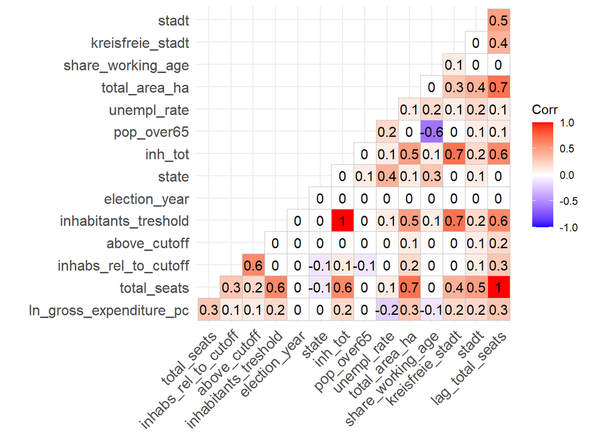

```r
d_rdd_balance_test %>%
  select(-c(inhabitants_treshold_factor, year, ags)) %>%
  cor(., use = "pairwise.complete.obs") %>%
  ggcorrplot::ggcorrplot(type = "lower", lab = TRUE, digits = 1)
```

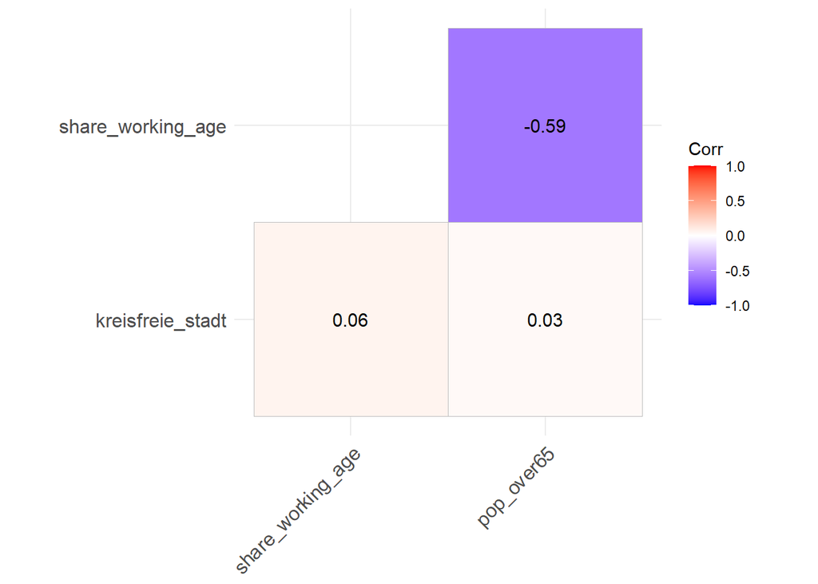

```r
d_rdd_balance_test %>%
  select(kreisfreie_stadt, share_working_age, pop_over65) %>%
  cor(., use = "pairwise.complete.obs") %>%
  ggcorrplot::ggcorrplot(type = "lower", lab = TRUE)
```